# hw1

yang an

2024-10-17

## question

###1. Five articles are provided on the book author’s web site (https://robweiss.faculty.biostat.ucla.edu/biostat236)

####(1)Counsell et al 2007

1. Does this article analyze longitudinally collected data? Yes, this study follows participants over a 2-year period.
2. How many repeated measurements were taken over time? 5 times,the study includes assessments at baseline and follow-up assessments at 6, 12, 18, and 24 months.
3. When were they taken, measuring from baseline? Measurements were taken at 6, 12, 18, and 24 months from the baseline.
4. longitudinal analysis? Yes, the authors used a longitudinal analysis to track changes over time.
5. analysis name? The authors used mixed-effects regression models to assess the intervention effect on outcomes.
6. Name two key responses. The Medical Outcomes Study 36-Item Short-Form Health Survey (SF-36) scales; Activities of daily living (ADLs).
7. What covariates were used? Covariates included age, gender, comorbidities, and baseline health status.
8. What software was used? The study used SAS software version 9.1.

####(2)HLP working group 2007

1. Does this article analyze longitudinally collected data? Yes, this study followed participants over a period of 25 months.
2. How many repeated measurements were taken over time? 6 times, five measurements were taken at 5, 10, 15, 20, and 25 months after randomization.
3. When were they taken, measuring from baseline? The measurements were taken at 5-month intervals starting from baseline.
4. longitudinal analysis? Yes, the authors used longitudinal methods.
5. analysis name? A random effects Poisson regression model was used in an intention-to- treat analysis.
6. Name two key responses.

Transmission risk (number of unprotected sexual acts). Psychological coping and quality of life. (g) What covariates were used? Covariates included age, gender, city, race, education, employment status and so on.

8. What software was used? Authors used the SAS GLIMMIX28 macro (SAS Institute, Cary, NC) to fit the random effects models, PROC LOGISTIC (SAS Institute, Cary, NC) to estimate propensity scores, and PROC MIANALYZE (SAS Institute, Cary, NC) to compute the significance levels combined across the 4 imputed data sets.

####(3)Ponsford et al 2014

1. Does this article analyze longitudinally collected data? Yes, this study tracks patients with traumatic brain injury over a period of 10 years.
2. How many repeated measurements were taken over time? 4times, three measurements were taken at 2, 5, and 10 years post-injury.
3. When were they taken, measuring from baseline? Measurements were taken at 2, 5, and 10 years from the baseline (the time of injury).
4. longitudinal analysis? Yes, the authors employed longitudinal analysis.
5. analysis name? Cochran’s Q test analysis. Glasgow Outcome Scale-Extended (GOSE).
6. Name two key responses.

Mobility. Cognition, behavior, emotion, and communication.

7. What covariates were used? Covariates included injury severity, age at injury, and other demographic factors.
8. What software was used? SPSS v20.0.

####(4)Rabiolo et al 2020 (a) Does this article analyze longitudinally collected data? Yes, this study follows patients with glaucoma over a period of at least 2 years.

2. How many repeated measurements were taken over time? At least five OCT images and visual field tests were taken during the follow-up period.
3. When were they taken, measuring from baseline? Measurements were taken over a 4.5-year median follow-up period.
4. longitudinal analysis? Yes, the study used longitudinal analysis to track disease progression.
5. analysis name? Linear regression models were used. Pairwise differences among the measures of interest were tested with Tukey test.
6. Name two key responses. Full macular thickness (FMT). Ganglion cell complex (GCC) thickness.
7. What covariates were used? Covariates included age, baseline visual field damage, and baseline thickness of retinal layers.
8. What software was used? Automated segmentation of individual retinal layers was performed with the Glaucoma Module Premium Edition software before data export. The study used Heidelberg Engineering software for OCT analysis

####(5) Li et al 2021 (a) Does this article analyze longitudinally collected data? Yes, this study uses weekly COVID-19 data at the county level in the United States.

2. How many repeated measurements were taken over time? 40 repeated weekly measurements per county were used in the analysis.
3. When were they taken, measuring from baseline? Weekly data were collected from March 2020 through December 2020.
4. longitudinal analysis? Yes, the authors used generalized linear mixed models to analyze the data.
5. analysis name? Generalized linear mixed models (GLMM) were used for both cumulative and weekly case and death rates.
6. Name two key responses.

COVID-19 case rates. COVID-19 death rates.

7. What covariates were used? Covariates included socioeconomic disadvantage, comorbidities, and Metro/Non-Metro classification.
8. What software was used? The analysis was conducted using R.

###2. Problem 12, chapter 1, page 26.

answers: (a) Balanced with no missing data (b) Balanced with missing data (c) balanced with missing data (d) Balanced with missing data (e) unbalanced, has random times (f) Balanced with missing data

```r
library(GGally)
library(tidyverse)
library(Rmisc)
setwd('/Users/yangan/Desktop/M236/M236-Lab/')

options(scipen = 999)


# Use read.table and specify the correct separator
small_mice <- read.table("smallmice.txt", header = TRUE, sep = "\t")  # For tab-separated
big_mice <- read.table("bigmice.txt", header = TRUE, sep = "\t")
pediatric_pain <- read.table("Pediatric Pain long format.txt", header = TRUE, sep = "\t")
weight_loss <- read.table("Weight Loss Version1(weekly observations).txt", header = TRUE, sep = "\t")
bsi_total <- read.table("BSI Total.txt", header = TRUE, sep = "\t")
cognitive <- read.table("Cognitive.txt", header = TRUE, sep = "\t")
```

```r
# Print the first few rows of each dataset to explore
head(small_mice)
```

```
##   Group id weight day
## 1     3 22    190   2
## 2     3 22    388   5
## 3     3 22    621   8
## 4     3 22    823  11
## 5     3 22   1078  14
## 6     3 22   1132  17
```

```r
head(big_mice)
```

```
##   group id weight day dday cday
## 1     1  1    120   0    0  -10
## 2     1  1     NA   1    1   -9
## 3     1  1     NA   2    2   -8
## 4     1  1    138   3    3   -7
## 5     1  1     NA   4    4   -6
## 6     1  1     NA   5    5   -5
```

```r
head(pediatric_pain)
```

```
##   id  ses       cs     treatment    sex       age trial paintol l2paintol
## 1  1 73.5 attender        attend female 10.083333     1   20.55  4.361066
## 2  1 73.5 attender        attend female 10.083333     2   35.31  5.142005
## 3  1 73.5 attender        attend female 10.083333     3   14.29  3.836934
## 4  1 73.5 attender        attend female 10.083333     4   11.71  3.549669
## 5  3 81.5 attender no directions female  8.666667     1   12.00  3.584963
## 6  3 81.5 attender no directions female  8.666667     2   10.00  3.321928
```

```r
head(weight_loss)
```

```
##   id weight week
## 1  1  188.4    1
## 2  1  188.4    2
## 3  1  185.8    3
## 4  1  182.0    4
## 5  1  182.0    5
## 6  1  188.4    6
```

```r
head(bsi_total)
```

```
##   pid study_month gender age_at_baseline  age true_month rounded3_true_month
## 1  11           0   male            16.2 16.2   0.000000                   0
## 2  11           6   male            16.2 17.1   9.921971                   9
## 3  11          24   male            16.2 18.5  26.743326                  27
## 4  11          30   male            16.2 19.3  36.336756                  36
## 5  11          36   male            16.2 19.6  40.673511                  42
## 6  11          42   male            16.2 19.9  44.024641                  45
##   treatment parent_died parent_alcohol parent_marijuana drug_status
## 1         0          no             NA               NA
## 2         0          no             NA               NA
## 3         0          no              0                0     nonuser
## 4         0          no              0                0     nonuser
## 5         0          no              0                0     nonuser
## 6         0          no              0                0     nonuser
##               season   bsi_dep   bsi_anx   bsi_ocd bsi_sens bsi_host bsi_phob
```

[output cut: 20 more lines]

```r
head(cognitive)
```

```
##   id schoolid treatment rn relyear ravens arithmetic vmeaning dstotal  sex
## 1  1        2      meat  1   -0.15     15          5       25       6 girl
## 2  1        2      meat  2    0.14     19          7       39       8 girl
## 3  1        2      meat  3    0.46     21          7       33       7 girl
## 4  1        2      meat  4    1.19     18          8       37       7 girl
## 5  1        2      meat  5    1.74     21         10       37       8 girl
## 6  2        9   control  1   -0.10     18          8       29       6 girl
##   age_at_time0 height weight head_circ ses1 readtest writetest yrsofsch
## 1         7.19 110.15   17.8     50.25   89       12        11        7
## 2         7.19 110.15   17.8     50.25   89       12        11        7
## 3         7.19 110.15   17.8     50.25   89       12        11        7
## 4         7.19 110.15   17.8     50.25   89       12        11        7
## 5         7.19 110.15   17.8     50.25   89       12        11        7
## 6         8.08 122.65   22.1     51.00  106       12        11        7
##   morbscore complete rnone relmonth old morbcut ravensobs beforezero
## 1      0.53        1     1    -1.80   0       0         1          1
## 2      0.53        1     0     1.68   0       0         1          0
## 3      0.53        1     0     5.52   0       0         1          0
## 4      0.53        1     0    14.28   0       0         1          0
## 5      0.53        1     0    20.88   0       0         1          0
## 6      1.00        1     1    -1.20   0       1         1          1
```

```r
# Check if all the IDs have the same number of measurements(var-freq)
table(small_mice$id)
```

```
##
## 22 23 24 25 26 27 28 29 30 31 32 33 34 35
##  7  7  7  7  7  7  7  7  7  7  7  7  7  7
```

```r
table(big_mice$id)
```

```
##
##  1  2  3  4  5  6  7  8  9 10 11 12 13 14 15 16 17 18 19 20 21 22 23 24 25 26
## 21 21 21 21 21 21 21 21 21 21 21 21 21 21 21 21 21 21 21 21 21 21 21 21 21 21
## 27 28 29 30 31 32 33 34 35
## 21 21 21 21 21 21 21 21 21
```

```r
table(pediatric_pain$id)
```

```
##
##  1  2  3  4  5  6  7  8  9 10 11 12 13 14 15 16 17 18 19 20 21 22 23 24 25 26
##  4  4  4  4  4  4  4  4  4  4  4  4  4  4  4  4  4  4  4  4  4  4  4  4  4  4
## 27 28 29 30 31 32 33 34 35 36 37 38 39 40 41 42 43 44 45 46 47 48 49 50 51 52
##  4  4  4  4  4  4  4  4  4  4  4  4  4  4  4  4  4  4  4  4  4  4  4  4  4  4
## 53 54 55 56 57 58 59 60 61 62 63 64
##  4  4  4  4  4  4  4  4  4  4  4  4
```

```r
table(weight_loss$id)
```

```
##
##  1  2  3  4  5  6  7  8  9 10 11 12 13 14 15 16 17 18 19 20 21 22 23 24 25 26
##  8  8  8  8  8  8  8  8  8  8  8  8  8  8  8  8  8  8  8  8  8  8  8  8  8  8
## 27 28 29 30 31 32 33 34 35 36 37 38
##  8  8  8  8  8  8  8  8  8  8  8  8
```

```r
table(bsi_total$pid)
```

```
##
##   11   21   22   31   32   41   51   61   62   71   81   82   91  101  111  121
##   12   13   12    9   12   10   10   10   13    8   14   14    5    7   14   16
##  131  132  141  151  161  171  181  182  191  201  202  211  221  222  231  241
##   11   13    4   12   16   11   11   13   13    5   13   11   15   16   17    7
##  251  261  262  271  281  282  283  284  291  301  311  312  313  321  322  331
##   10    9   11    5    4    6    5   11    5   14   14   16   14   15   11    2
##  341  342  361  371  372  373  381  391  392  401  411  412  413  414  421  431
##   16   14   17    6   10    8    4    9   13   17   15   17   15   13   15   15
##  441  451  452  453  454  461  471  472  481  491  501  511  512  521  531  532
##   14   14   14   14   14    2   14   15    7   12    6   12   12   15   14   14
##  541  551  552  561  571  601  602  611  612  613  632  641  651  652  671  681
##    9    2   11   11   16   10   11   15   13   13   10   17   16   10    7   13
##  682  683  691  701  702  711  712  713  721  741  751  752  753  761  771  801
##   15   14   12    7   11   16   15   16   10   12   13   10   14   16   15   10
```

[output cut: 18 more lines]

```r
table(cognitive$id)
```

```
##
##   1   2   3   4   5   6   7   8   9  10  11  12  13  14  15  16  17  18  19  20
##   5   5   5   5   5   5   5   5   5   5   5   5   5   5   5   5   5   5   5   5
##  21  22  23  24  25  26  27  28  29  30  31  32  33  34  35  36  37  38  39  40
##   5   5   5   5   5   5   5   5   5   5   5   5   5   5   5   5   5   5   5   5
##  41  42  43  44  45  46  47  48  49  50  51  52  53  54  55  56  57  58  59  60
##   5   5   5   5   5   5   5   5   5   5   5   5   5   5   5   5   5   5   5   5
##  61  62  63  64  65  66  67  68  69  70  71  72  73  74  75  76  77  78  79  80
##   5   5   5   5   5   5   5   5   5   5   5   5   5   5   5   5   5   5   5   5
##  81  82  83  84  85  86  87  88  89  90  91  92  93  94  95  96  97  98  99 100
##   5   5   5   5   5   5   5   5   5   5   5   5   5   5   5   5   5   5   5   5
## 101 102 103 104 105 106 107 108 109 110 111 112 113 114 115 116 117 118 119 120
##   5   5   5   5   5   5   5   5   5   5   5   5   5   5   5   5   5   5   5   5
## 121 122 123 124 125 126 127 128 129 130 131 132 133 134 135 136 137 138 139 140
##   5   5   5   5   5   5   5   5   5   5   5   5   5   5   5   5   5   5   5   5
```

[output cut: 42 more lines]

```r
# Check missingness in each dataset
sum(is.na(small_mice))
```

```
## [1] 0
```

```r
sum(is.na(big_mice))
```

```
## [1] 462
```

```r
sum(is.na(pediatric_pain))
```

```
## [1] 34
```

```r
sum(is.na(weight_loss))
```

```
## [1] 39
```

```r
sum(is.na(bsi_total))
```

```
## [1] 3258
```

```r
sum(is.na(cognitive))
```

```
## [1] 3237
```

###3.

```
##   height weight ses WRITETEST READTEST ID        time gender   group Bage
## 1 115.80   19.4 123        NA       NA  1 -0.09856263   girl calorie  6.9
## 2     NA   19.9 123        NA       NA  1  0.06023272   girl calorie  6.9
## 3     NA   20.3 123        NA       NA  1  0.15331964   girl calorie  6.9
## 4 118.70   20.2 123        NA       NA  1  0.22724162   girl calorie  6.9
## 5     NA   20.8 123        NA       NA  1  0.29295003   girl calorie  6.9
## 6 105.75   17.3 109         0        0  2 -0.09856263   girl calorie  5.4
```

1. the earliest time

```
## Earliest time (in days): -60
```

the earliest time of any measurement is -60.

2. the latest time

```r
# the latest time of any measurement
latest_time <- max(anthropometry$time_days, na.rm = TRUE)
cat("Latest time (in days):", latest_time, "\n")
```

```
## Latest time (in days): 924
```

3. the nominal times the nominal time is below:

```
## # A tibble: 8,402 × 13
##    height weight   ses WRITETEST READTEST    ID    time gender group    Bage
##     <dbl>  <dbl> <int>     <int>    <int> <int>   <dbl> <chr>  <chr>   <dbl>
##  1   116.   19.4   123        NA       NA     1 -0.0986 girl   calorie   6.9
##  2    NA    19.9   123        NA       NA     1  0.0602 girl   calorie   6.9
##  3    NA    20.3   123        NA       NA     1  0.153  girl   calorie   6.9
##  4   119.   20.2   123        NA       NA     1  0.227  girl   calorie   6.9
##  5    NA    20.8   123        NA       NA     1  0.293  girl   calorie   6.9
##  6   106.   17.3   109         0        0     2 -0.0986 girl   calorie   5.4
##  7    NA    17.8   109         0        0     2  0.0602 girl   calorie   5.4
##  8    NA    18     109         0        0     2  0.153  girl   calorie   5.4
##  9   108.   18.2   109         0        0     2  0.227  girl   calorie   5.4
## 10    NA    18.3   109         0        0     2  0.405  girl   calorie   5.4
## # ℹ 8,392 more rows
## # ℹ 3 more variables: time_days <dbl>, obs <int>, nominal_time <dbl>
```

```
## # A tibble: 18 × 2
##      obs nominal_time
##    <int>        <dbl>
##  1     1        -22.2
##  2     2         22.6
##  3     3         57.2
##  4     4         86.2
##  5     5        112.
##  6     6        145.
##  7     7        174.
##  8     8        206.
##  9     9        242.
## 10    10        330.
## 11    11        393.
## 12    12        454.
## 13    13        519.
## 14    14        578.
## 15    15        638.
## 16    16        709.
## 17    17        852.
## 18    18        906.
```

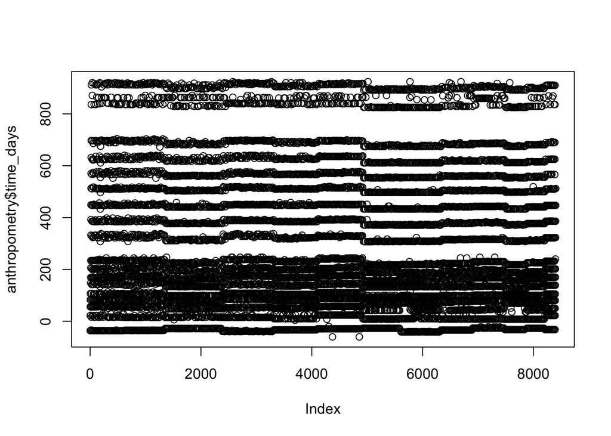

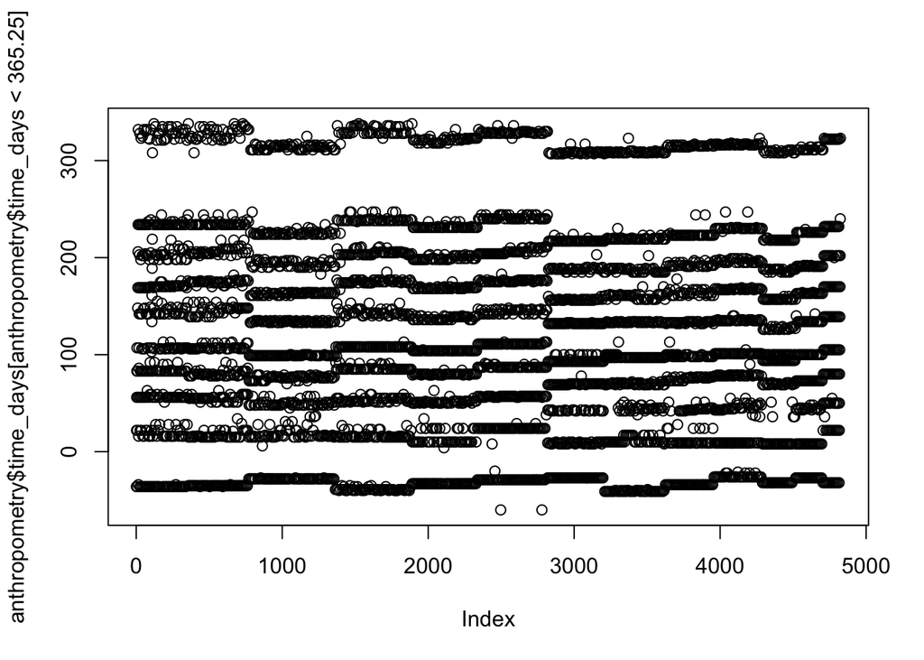

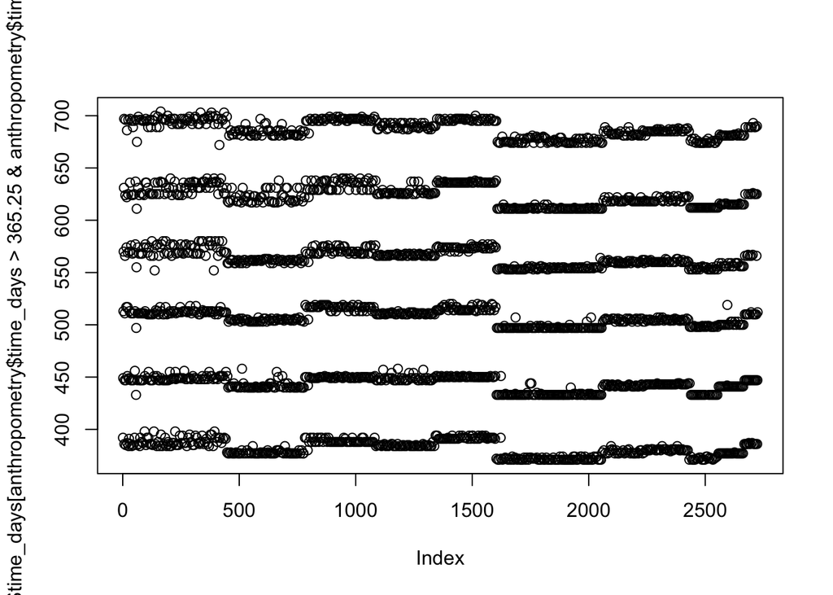

For the first year, it seems that the data was collected every 30 days. For the second year, the data was collected every 50 or 60 days. It is a little bit more spread out. In conclusion, the frequency of observations changes over time, and first-year data is collected more frequently than second-year data.

4. subjects number

Subjects with observations within 2 days: 0 Subjects with observations within 10 days: 133 Subjects with observations within 20 days: 350 there are 0 subjects with observations within 2 days, 133 subjects with observations within 10 days, and 350 subjects with observations within 20 days.

5. impact

```
## Mean height before 20 days: 115.7216
```

```
## Mean height after 20 days: 122.3249
```

```
## Height trend: 6.603292
```

```
## Mean weight before 20 days: 20.13963
```

```
## Mean weight after 20 days: 22.18967
```

```
## Weight trend: 2.050035
```

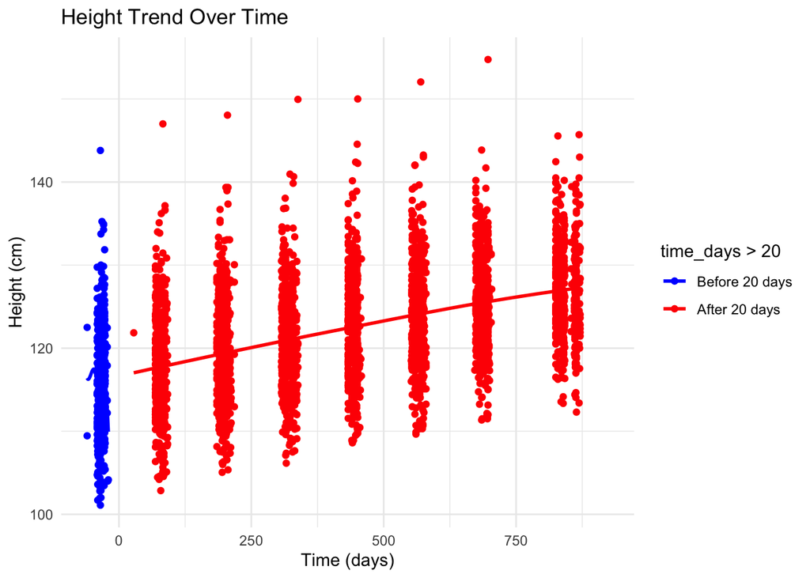

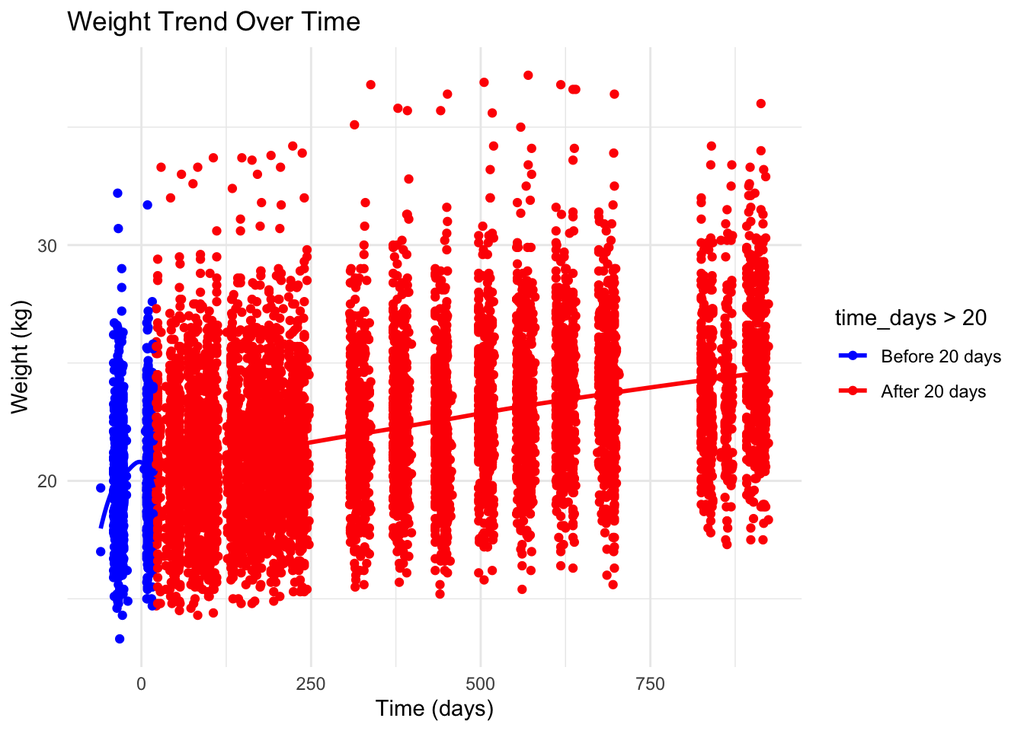

```
##
##  Welch Two Sample t-test
##
## data:  before_20_days$height and after_20_days$height
## t = -21.556, df = 689.44, p-value < 0.00000000000000022
## alternative hypothesis: true difference in means is not equal to 0
## 95 percent confidence interval:
##  -7.204754 -6.001830
## sample estimates:
## mean of x mean of y
##  115.7216  122.3249
```

```
##
##  Welch Two Sample t-test
##
## data:  before_20_days$weight and after_20_days$weight
## t = -20.935, df = 1143.8, p-value < 0.00000000000000022
## alternative hypothesis: true difference in means is not equal to 0
## 95 percent confidence interval:
##  -2.242169 -1.857901
## sample estimates:
## mean of x mean of y
##  20.13963  22.18967
```

Mean height before 20 days is 115.7216, Mean height after 20 days is 122.3249, Height trend is 6.603292, Mean weight before 20 days is 20.13963, Mean weight after 20 days is 22.18967,Weight trend is 2.050035. Both height and weight have increased over time. The p-value for both height and weight is less than 0.05, which indicates that the mean difference before and after 20 days is statistically significant. This suggests that there is a significant impact on height and weight over time in the dataset. However, the plots show that the trends are natural gradual changes rather than sudden shifts. As a result, the impact may be due to normal growth and development rather than an treatment effect. Further analysis and context would be needed to determine the cause of these trends.

6. weight outcome measure

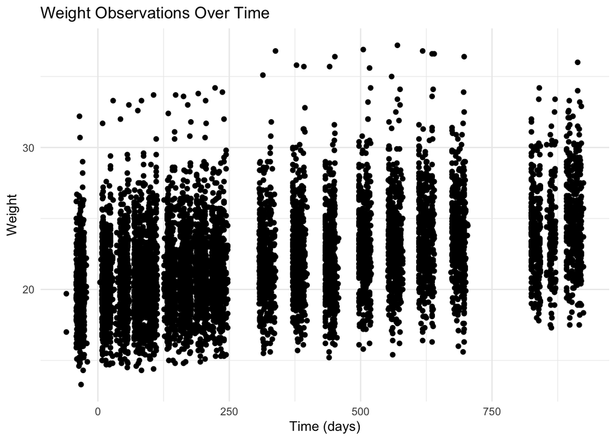

```r
# Explore the actual times of weight observations
ggplot(anthropometry, aes(x = time_days, y = weight)) +
  geom_point() +
  labs(title = "Weight Observations Over Time",
       x = "Time (days)",
       y = "Weight") +
  theme_minimal()
```

```r
# Check unique observation times for weight
unique_times_weight <- anthropometry %>%
  filter(!is.na(weight)) %>%
  arrange(time_days) %>%
  select(time_days) %>%
  distinct()

cat("Unique times of weight observations (in days):", unique_times_weight$time_days, "\n")
```

```
## Unique times of weight observations (in days): -60 -41 -40 -39 -36 -35 -34 -33 -32 -29 -28 -27 -26 -22 -21 -20 4 6 8 9 10 15 16 17 18 21 22 23 24 27 28 29 31 34 36 37 38 42 43 44 45 48 50 51 52 55 56 57 59 63 69 70 71 72 73 76 77 78 79 80 83 84 85 86 87 90 91 92 93 94 95 97 98 99 100 101 103 104 …
```

```r
# Count weight observations in the first year (within 365.25 days)
first_year_weight <- anthropometry %>%
  filter(time_days <= 365.25, !is.na(weight)) %>%
  dplyr::summarise(first_year_count = dplyr::n())

# Print the result
cat("First year weight observations:", first_year_weight$first_year_count, "\n")
```

```
## First year weight observations: 4824
```

```r
# Count weight observations in the second year (between 365.25 and 730.5 days)
second_year_weight <- anthropometry %>%
  filter(time_days > 365.25 & time_days <= 730.5, !is.na(weight)) %>%
  dplyr::summarise(second_year_count = dplyr::n())

# Print the result
cat("Second year weight observations:", second_year_weight$second_year_count, "\n")
```

```
## Second year weight observations: 2725
```

7. height outcome

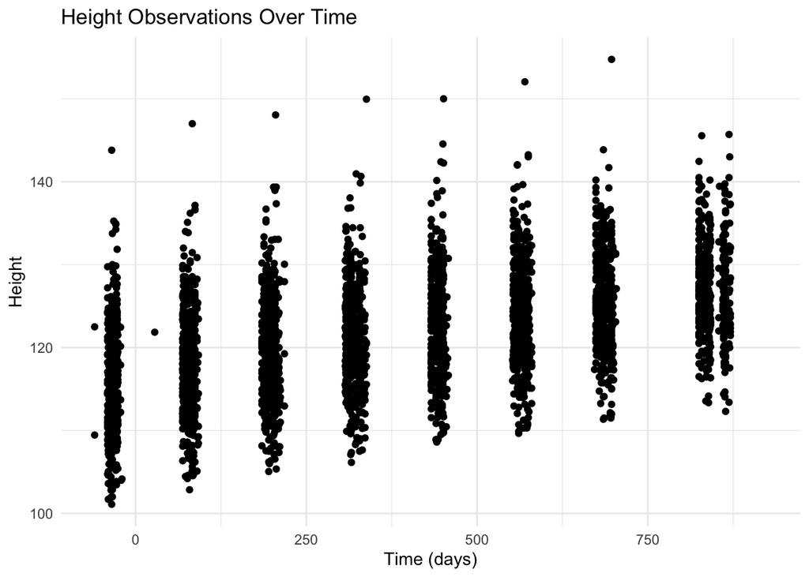

```r
# Explore the actual times of height observations
ggplot(anthropometry, aes(x = time_days, y = height)) +
  geom_point() +
  labs(title = "Height Observations Over Time",
       x = "Time (days)",
       y = "Height") +
  theme_minimal()
```

```r
# Check unique observation times for height
unique_times_height <- anthropometry %>%
  filter(!is.na(height)) %>%
  arrange(time_days) %>%
  select(time_days) %>%
  distinct()

cat("Unique times of height observations (in days):", unique_times_height$time_days, "\n")
```

```
## Unique times of height observations (in days): -60 -41 -40 -39 -36 -35 -34 -33 -32 -29 -28 -27 -26 -22 -21 -20 28 69 70 71 72 73 76 77 78 79 80 83 84 85 86 87 90 91 92 185 188 189 190 191 192 195 196 197 198 199 200 202 203 204 205 206 209 210 211 212 218 307 308 309 310 311 314 315 316 317 318 3…
```

```r
# Count height observations in the first year (within 365.25 days)
first_year_height <- anthropometry %>%
  filter(time_days <= 365.25, !is.na(height)) %>%
  dplyr::summarise(first_year_count = dplyr::n())

# Print the result
cat("First year height observations:", first_year_height$first_year_count, "\n")
```

```
## First year height observations: 1936
```

```r
# Count height observations in the second year (between 365.25 and 730.5 days)
second_year_height <- anthropometry %>%
  filter(time_days > 365.25 & time_days <= 730.5, !is.na(height)) %>%
  dplyr::summarise(second_year_count = dplyr::n())

# Print the result
cat("Second year height observations:", second_year_height$second_year_count, "\n")
```

```
## Second year height observations: 1355
```

(h)the frequencies

```r
# Compare observations by year (first year vs second year)

# First year height observations (<= 365.25 days)
height_first_year <- anthropometry %>%
  filter(time_days <= 365.25, !is.na(height)) %>%
  dplyr::summarise(first_year_height = dplyr::n())

# Second year height observations (> 365.25 days & <= 730.5 days)
height_second_year <- anthropometry %>%
  filter(time_days > 365.25 & time_days <= 730.5, !is.na(height)) %>%
  dplyr::summarise(second_year_height = dplyr::n())

# First year weight observations (<= 365.25 days)
weight_first_year <- anthropometry %>%
  filter(time_days <= 365.25, !is.na(weight)) %>%
  dplyr::summarise(first_year_weight = dplyr::n())

# Second year weight observations (> 365.25 days & <= 730.5 days)
weight_second_year <- anthropometry %>%
  filter(time_days > 365.25 & time_days <= 730.5, !is.na(weight)) %>%
  dplyr::summarise(second_year_weight = dplyr::n())

# Print the results for height and weight observations by year
cat("First year height observations:", height_first_year$first_year_height, "\n")
```

```
## First year height observations: 1936
```

```r
cat("Second year height observations:", height_second_year$second_year_height, "\n")
```

```
## Second year height observations: 1355
```

```r
cat("First year weight observations:", weight_first_year$first_year_weight, "\n")
```

```
## First year weight observations: 4824
```

```r
cat("Second year weight observations:", weight_second_year$second_year_weight, "\n")
```

```
## Second year weight observations: 2725
```

Comparison of Frequencies: There are more than double weight observations than height for both first and second year.

Possible reason: There are more weight observations compared to the height, which change slowly. As a result, the effect can be reflected more quick in weight, which fluctuate frequently and is suitable for a short term intervenction study.